# Bleaching investigation for Platy paper

Kristina Tietjen

03 March, 2020

**Tasks from Slack:**

1. create a new .Rmd / .html file (in the appropriate Platy Git repo) borrowing code from the tagged coral analysis we’ve been doing for KI Bleaching MS, and calculate the % of each of the 4 species that were bleached (and ideally also do a table for this in which we know which bleaching category they were i.e. how bleached) in July 2015 and in March/April 2016
2. from Kim’s Nov. 2015 data, create a spreadsheet (that we can then read into R and do calculations on) with data recorded for the Site, Coral Species, total number of individual colonies of that species that were visible in all photos at that site, total number of individual colonies of that species that were bleached. Then in R, calculate the proportion bleached: overall sites, and by disturbance level.
3. we should do the same for the SPQ data for July 2015 and March/April 2016 - will sort out these numbers with Jenn and Jessie as they’ve been the people primarily working with these data. (took the cleaned data from the bleaching repo that is from DM cleaning script)
4. compare the coral net version of proportion bleached from novebmer 2015 against the colony level proportion bleached that I tallied from the photos (from skype 2 Mar 20)

From i) and ii) I would like to then make a figure that shows the proportion bleached for each of the 4 species at these three time points. -> bar plot

Statistics: We could then do a series of simply models to quantify the following things:

1. What proportion of tagged coral colonies was bleached in 2015, and did this differ by species (ie. the 4 species) or disturbance level. Suggested model: mixed effects logistic regression with bleached/not-bleached as response, species and disturbance level as fixed effects, site as random effect.
2. same question but for Nov. 2015
3. What proportion of tagged coral colonies survived (i.e. March/April 2016 timepoint) and was survival higher at lower levels of disturbance (and did survival differ by species). Same type of model

**Relevant notes**

Bleaching levels  
* 1 = partial spotty/ patching bleaching (patches smaller than 5cm)  
* 2 = large patches greater than 5cm by not severe  
* 3 = severe or complete bleaching (~80% of the coral is bleached)  
* 4 = partial mortality but living tissue is not bleached

**example of level 4**

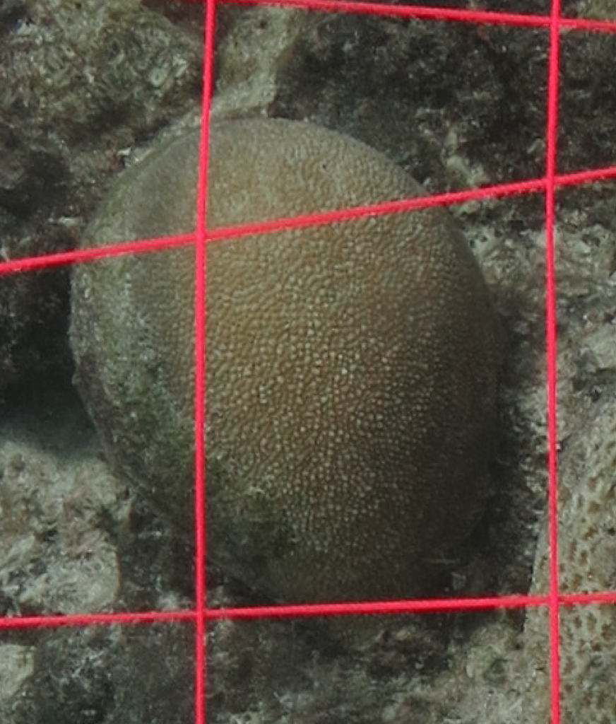

# i) metadata for 2015c and 2016a

## table of bleaching proportion

```
##       year          species.comb bleach.prop freq
## 1  KI2015c          Platygyra sp           0    2
## 2  KI2015c          Platygyra sp           1   13
## 3  KI2015c          Platygyra sp           2   16
## 4  KI2015c          Platygyra sp           3    6
## 5  KI2015c             Favia spp           0   11
## 6  KI2015c             Favia spp           1   15
## 7  KI2015c             Favia spp           2   24
## 8  KI2015c             Favia spp           3    3
## 9  KI2015c     Favites pentagona           0    6
## 10 KI2015c     Favites pentagona           1   12
## 11 KI2015c     Favites pentagona           2   13
## 12 KI2015c     Favites pentagona           3    7
## 13 KI2015c           Favites spp           1    3
## 14 KI2015c           Favites spp           2    3
```

[output cut: 21 more lines]

## bar plots

### overall

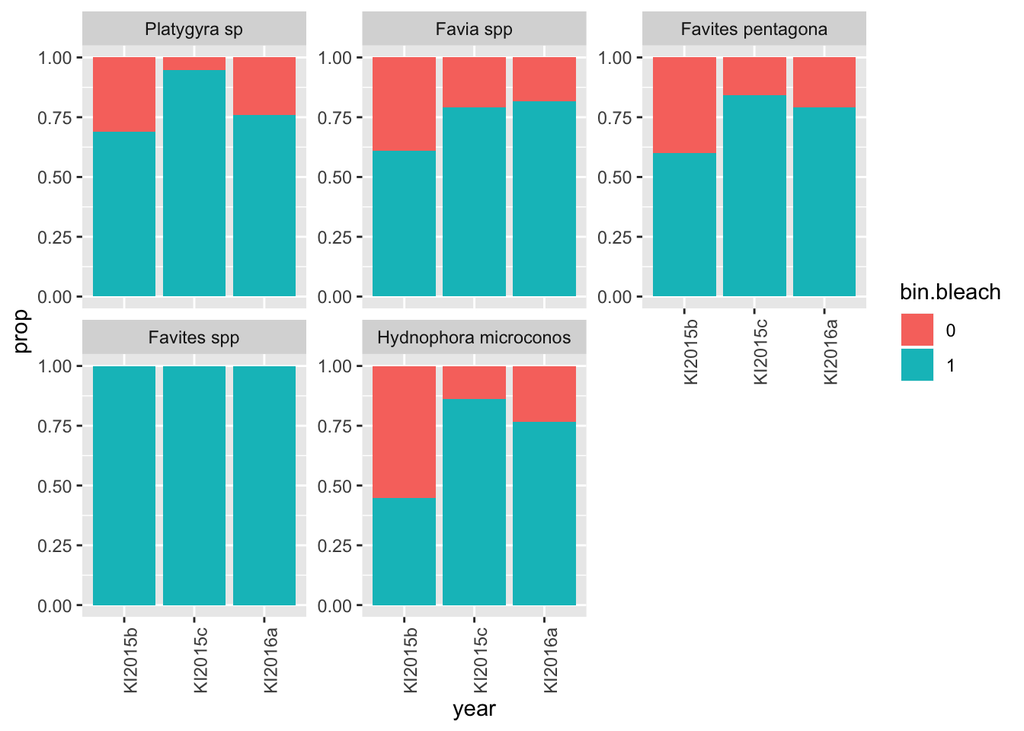

### year and level of bleaching

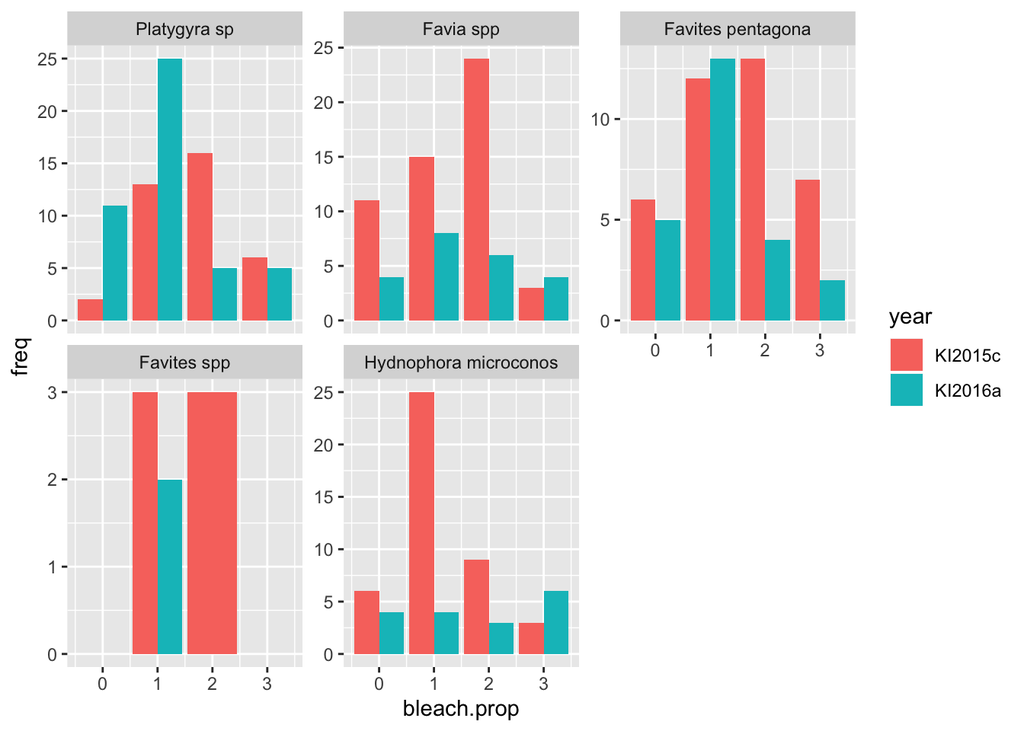

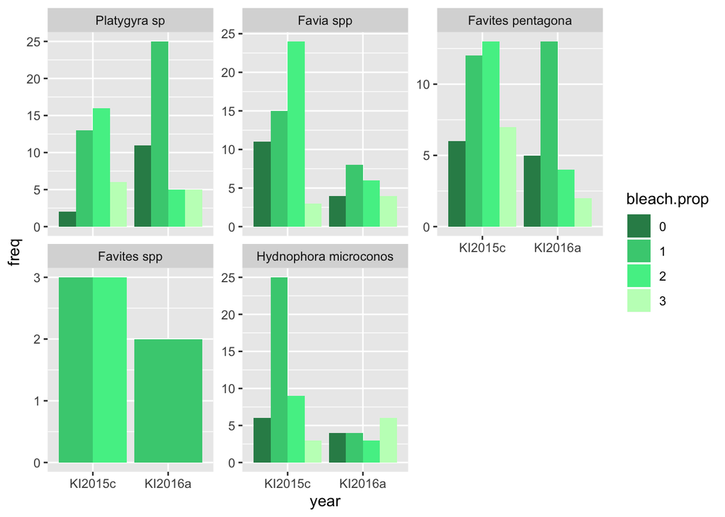

## statistics

**not bleached = 0 bleached (levels 1, 2, 3) = 1**

site not included as random effect due to not enough sites within each disturbance level (it would not converge)

```
##
## Call:
## glm(formula = bin.bleach ~ species.comb + disturb, family = binomial(link = "logit"),
##     data = metalong.sp15c)
##
## Deviance Residuals:
##     Min       1Q   Median       3Q      Max
## -3.1328   0.2278   0.4184   0.7148   0.8045
##
## Coefficients:
##                                    Estimate Std. Error z value Pr(>|z|)
## (Intercept)                          2.3919     0.7714   3.101  0.00193 **
## species.combFavia spp               -1.4298     0.8142  -1.756  0.07907 .
## species.combFavites pentagona       -1.2606     0.8674  -1.453  0.14613
## species.combFavites spp             14.7460  1590.5721   0.009  0.99260
## species.combHydnophora microconos   -1.3898     0.8739  -1.590  0.11177
## disturbMedium                        0.2321     0.5037   0.461  0.64493
## disturbLow                           0.8844     0.7185   1.231  0.21837
## disturbVery low                      2.5078     1.0865   2.308  0.02099 *
## ---
## Signif. codes:  0 '***' 0.001 '**' 0.01 '*' 0.05 '.' 0.1 ' ' 1
##
## (Dispersion parameter for binomial family taken to be 1)
##
##     Null deviance: 144.15  on 176  degrees of freedom
## Residual deviance: 127.55  on 169  degrees of freedom
## AIC: 143.55
##
## Number of Fisher Scoring iterations: 16
```

# ii) data from photos 2015d

## Notes

I (KT) went through every single photo and tallied each Merulinidae (except for F. speciosa and F. stelligara) that could be seen. The bleaching status of each was recorded using the scale above. I was very careful to not double count any coral that showed up in another photo. There is a category of Favid which are corals that I could tell were a favid but I was unable to tell if it was Favia or Favites.

I created a column in the datasheet when going through the data for if the coral was cut off or not. I said y when I estimated I could see less than 60% of the coral. Currently all corals I tallied (including ones that had a y for cut off) are included in the figures etc below.

## Calculations

**Platy**  
In the photos from Kim Cobb from November 2015 there were s 108 Platygyra. There were 92 that were not showing any signs of bleaching. That is 85.1851852% of the Platys. Only 9 had level 1 bleaching, 4 had level 2, and 2 had level 3.

**Hydno**  
In the photos from Kim Cobb from November 2015 there were s 175 Hydnophora. There were 45 that were not showing any signs of bleaching. That is 25.7142857% of the hydnos. Only 2 had level 1 bleaching, 8 had level 2, but 117 had level 3.

## table of bleaching proportion in November 2015

```
##                   site  species.comb bleach.prop bleach.prop.freq
## 1                   27 Platygyra sp.           0                3
## 2                   27 Platygyra sp.           1                1
## 3                   27  F. pentagona           0                1
## 4                   27     Favia spp           1                3
## 5                   27     Favia spp           3                2
## 6                   27         Favid           0                1
## 7                   27         Favid           2                2
## 8                   27    Hydnophora           0                4
## 9                   27    Hydnophora           3                1
## 10                  32 Platygyra sp.           0                8
## 11                  32 Platygyra sp.           1                4
## 12                  32 Platygyra sp.           2                2
## 13                  32 Platygyra sp.           4                1
## 14                  32  F. pentagona           1                3
```

[output cut: 63 more lines]

## bar plots

### facet wrap by species

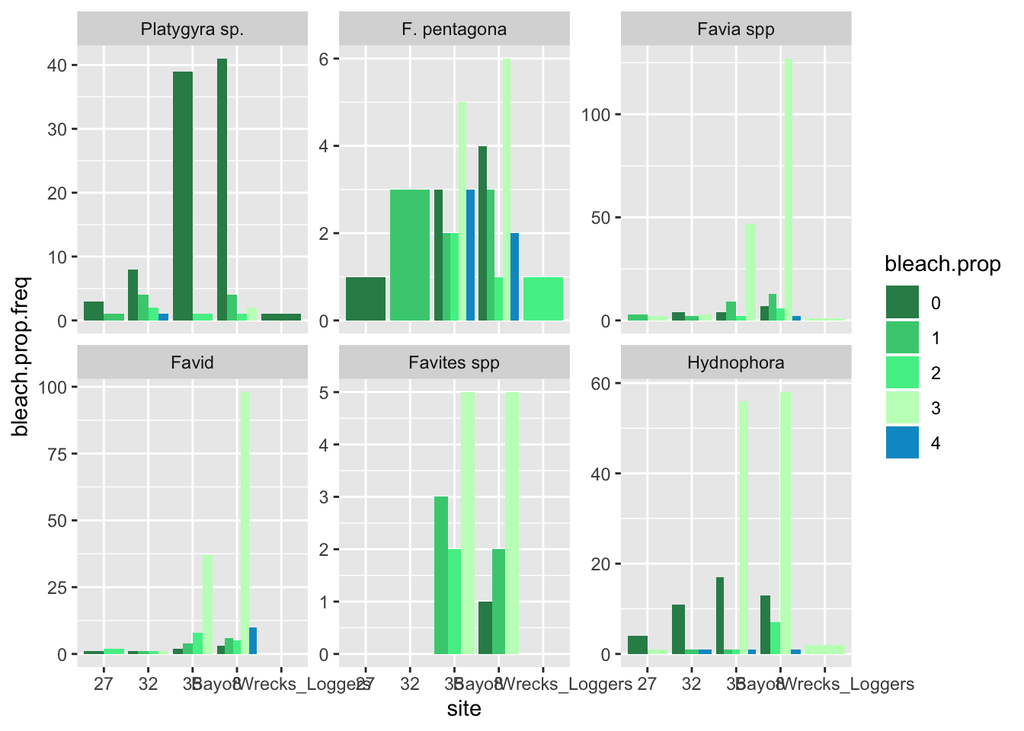

### facet wrap by site

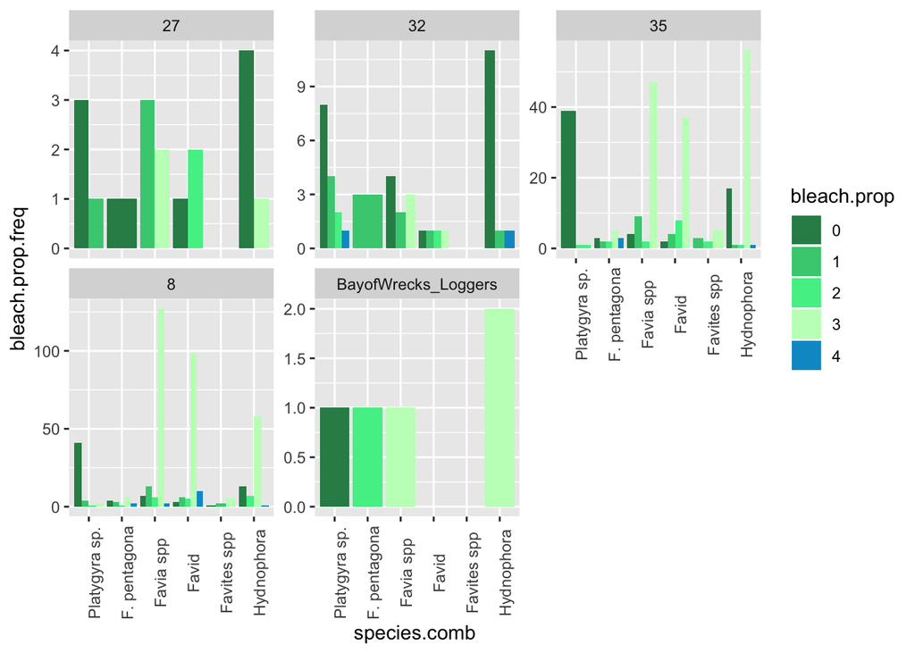

## statistics

**not bleached = 0 bleached (levels 1, 2, 3) = 1**

site not included as random effect due to not enough sites within each disturbance level (it would not converge)

```
##
## Call:
## glm(formula = bin.bleach ~ species.comb + disturb, family = binomial(link = "logit"),
##     data = nov15)
##
## Deviance Residuals:
##     Min       1Q   Median       3Q      Max
## -2.4043  -0.3241   0.3688   0.5077   2.4383
##
## Coefficients:
##                          Estimate Std. Error z value Pr(>|z|)
## (Intercept)               -2.9201     0.4198  -6.957 3.48e-12 ***
## species.combF. pentagona   2.3860     0.4526   5.271 1.35e-07 ***
## species.combFavia spp      4.3473     0.3796  11.451  < 2e-16 ***
## species.combFavid          3.6772     0.3575  10.287  < 2e-16 ***
## species.combFavites spp    4.5266     1.0671   4.242 2.22e-05 ***
## species.combHydnophora     2.8076     0.3306   8.492  < 2e-16 ***
## disturbM                   1.2267     0.3363   3.648 0.000264 ***
## disturbVL                  2.3390     1.3908   1.682 0.092619 .
## ---
## Signif. codes:  0 '***' 0.001 '**' 0.01 '*' 0.05 '.' 0.1 ' ' 1
##
## (Dispersion parameter for binomial family taken to be 1)
##
##     Null deviance: 865.29  on 755  degrees of freedom
## Residual deviance: 598.50  on 748  degrees of freedom
## AIC: 614.5
##
## Number of Fisher Scoring iterations: 5
```

# iii) coral net data 2015c, 2015d, 2016a

**important note**

2015d coral net is only 4 sites - 8, 35, 32, 27….  
Should I cut down all field seasons to just those four sites to make it actually comparable??

## over time all sites combined

requested by SS

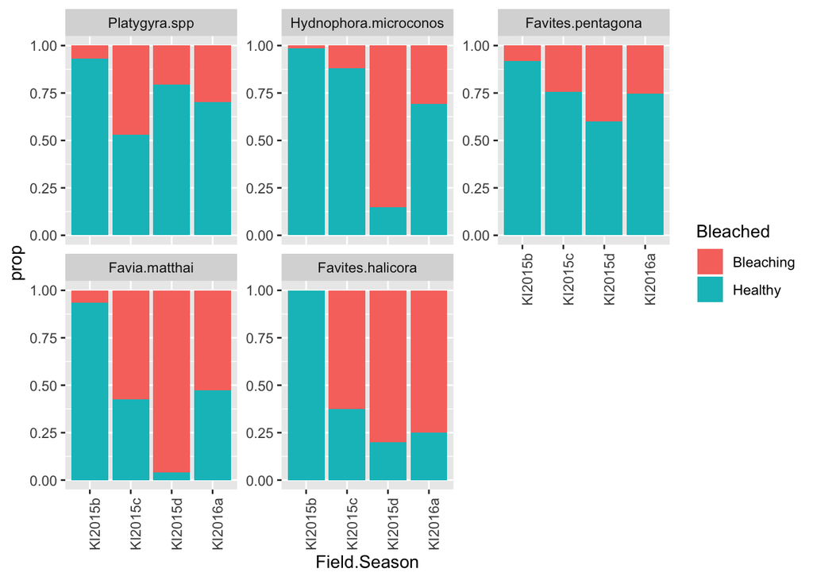

## bar plots

### proportion bleached vrs healthy per field season across sites with tagged corals

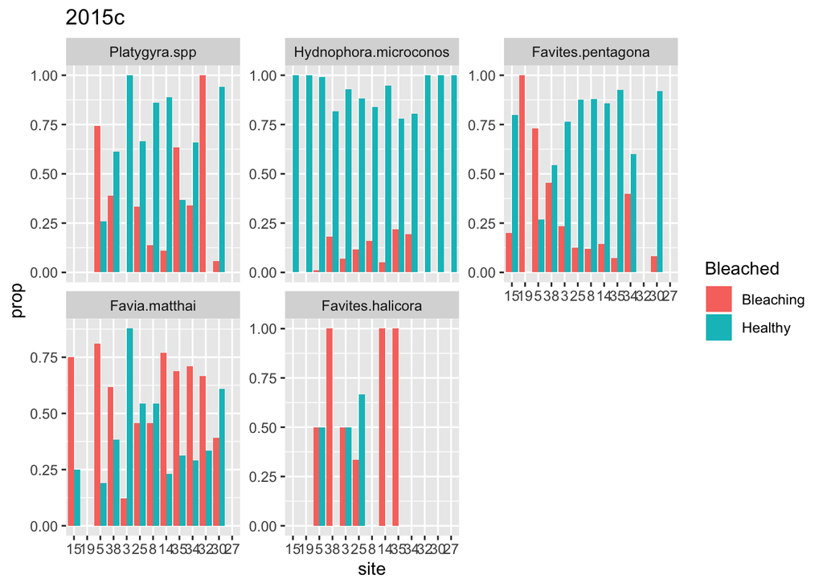

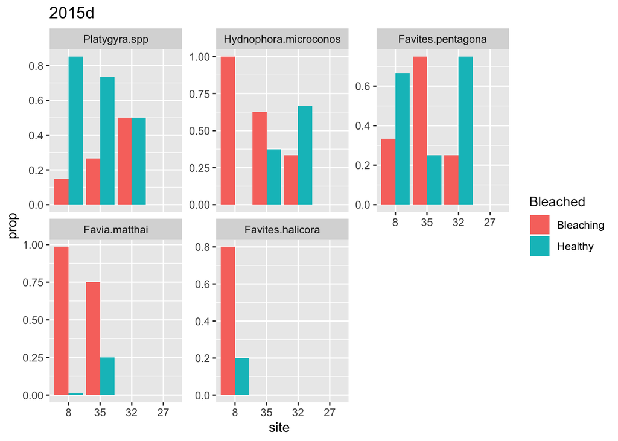

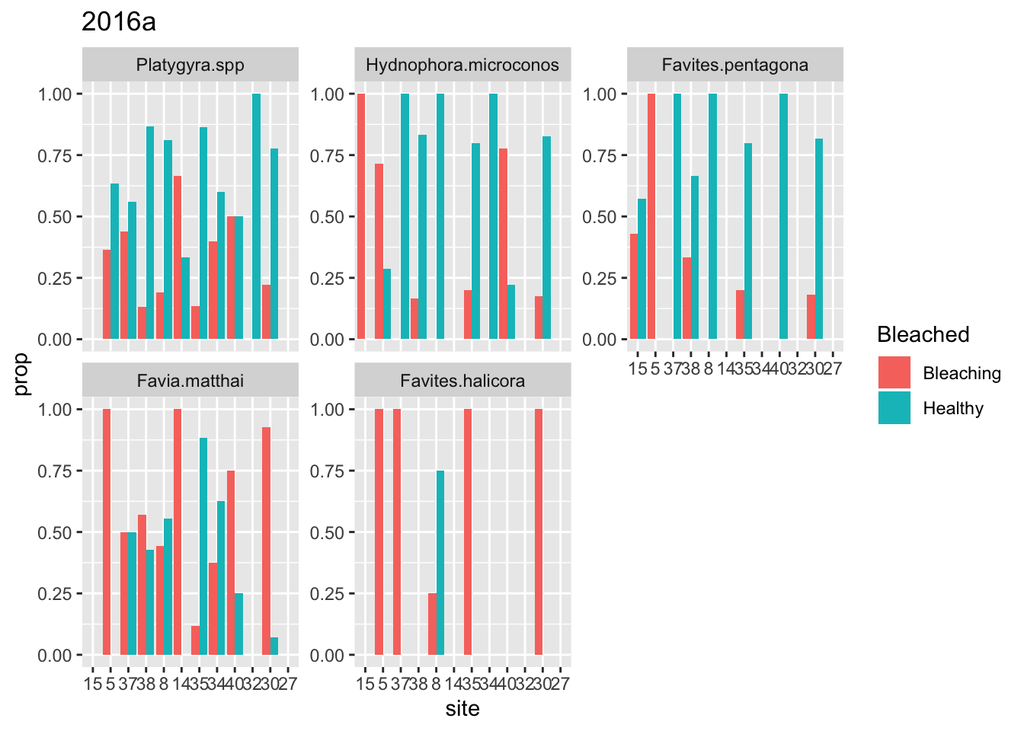

### across disturbance gradient (again only sites that have tagged corals)

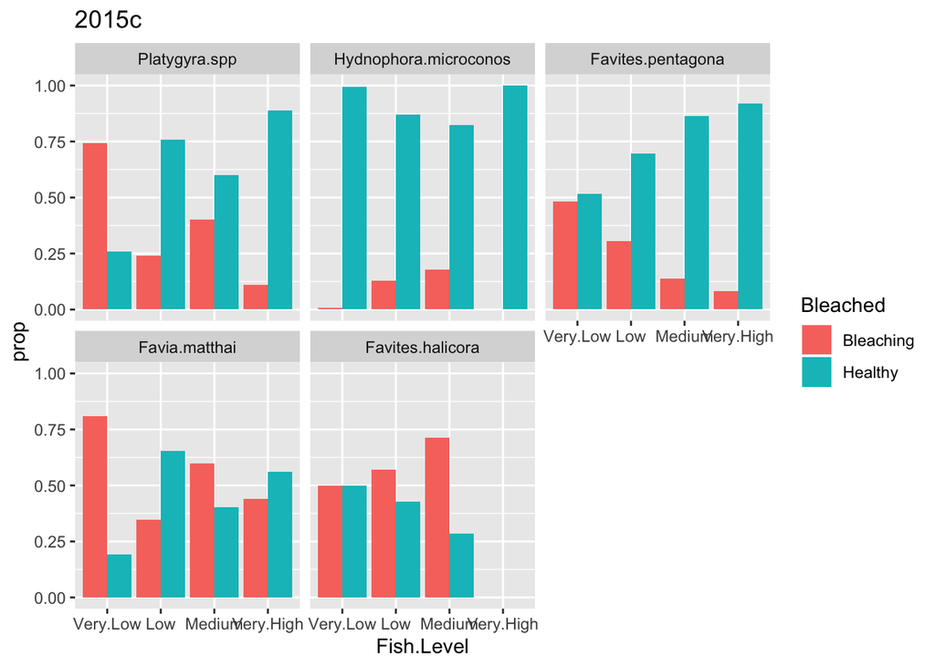

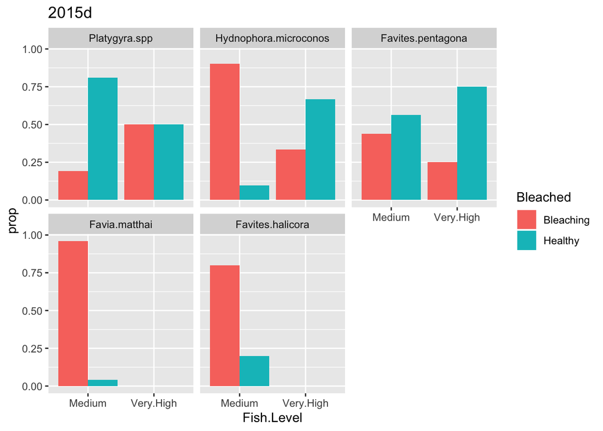

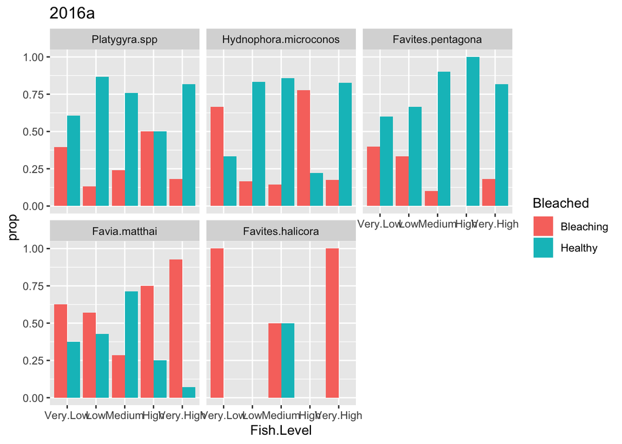

## bar plots but with only the 4 sites

### proportion bleached vrs healthy per field season across the 4 sites

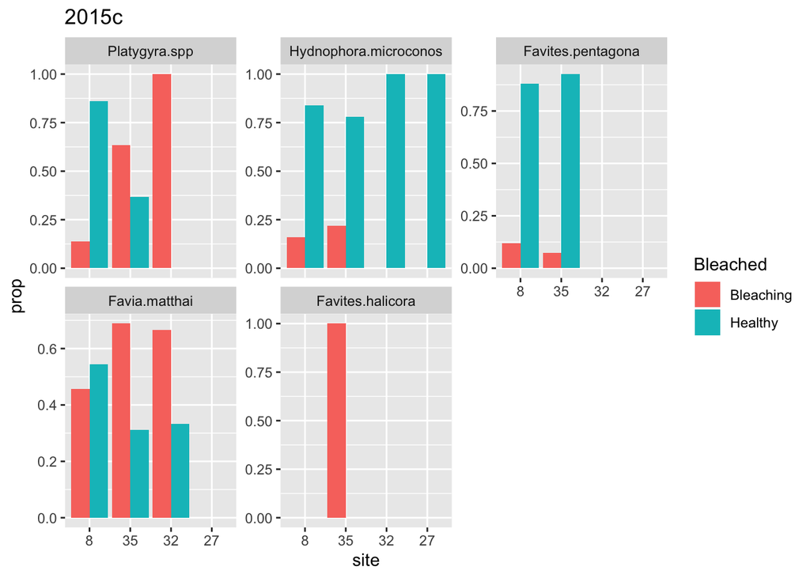

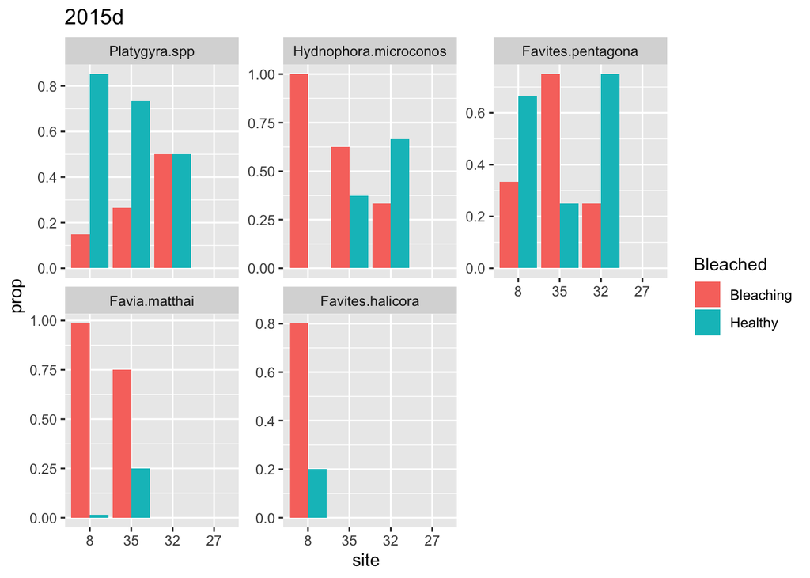

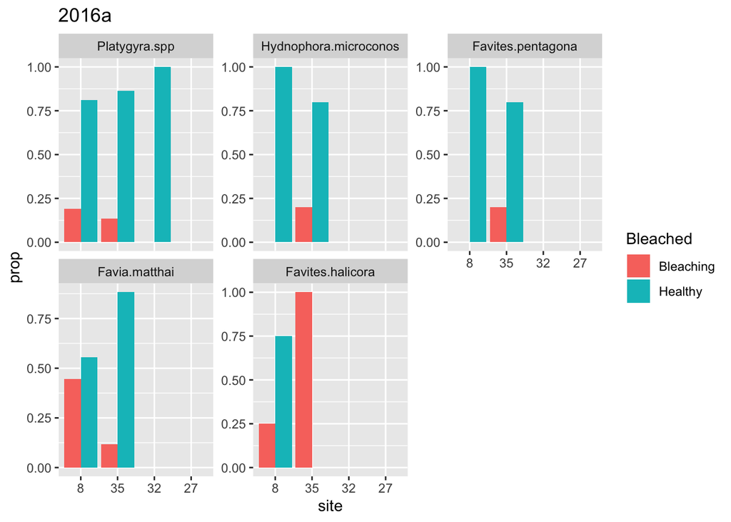

### across disturbance gradient (again only the four sites)

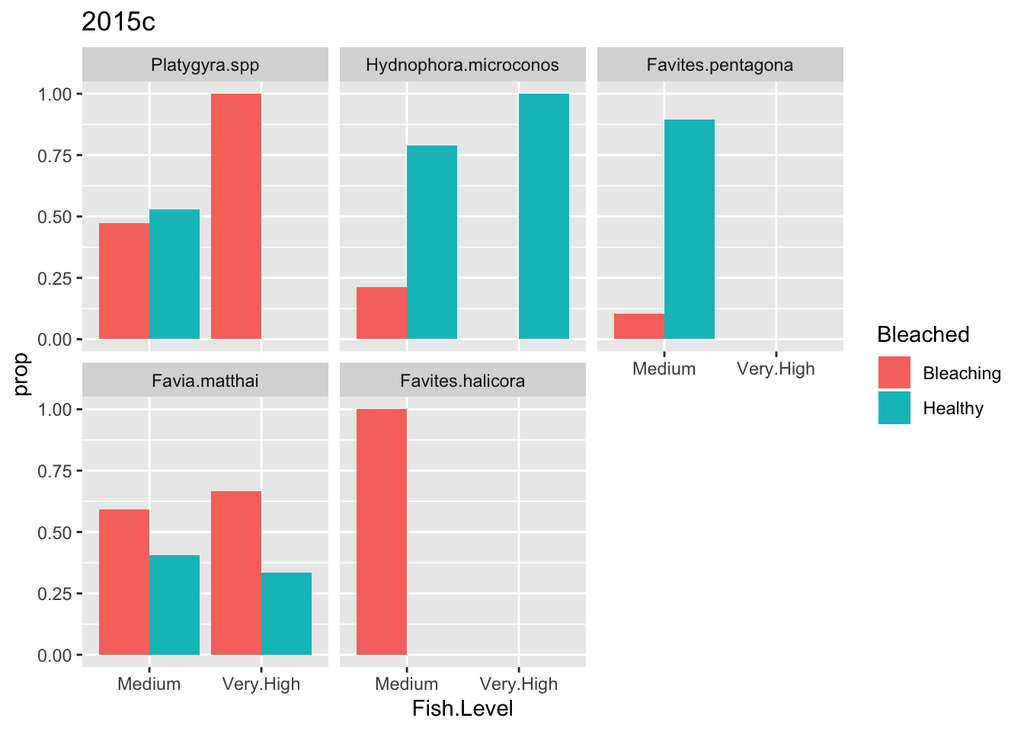

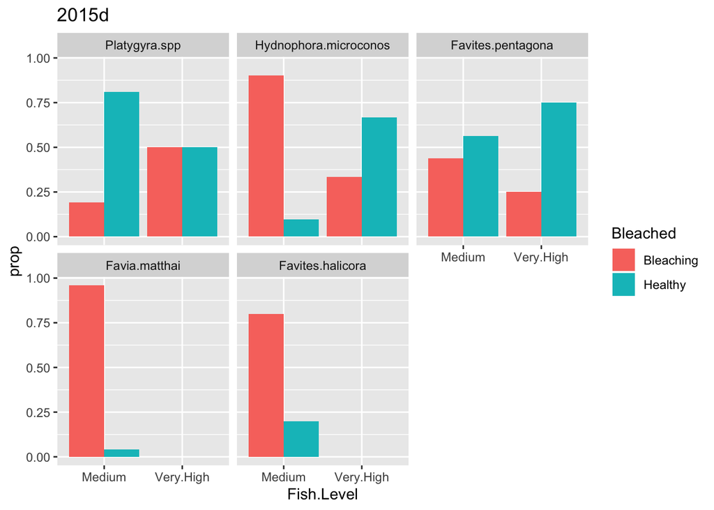

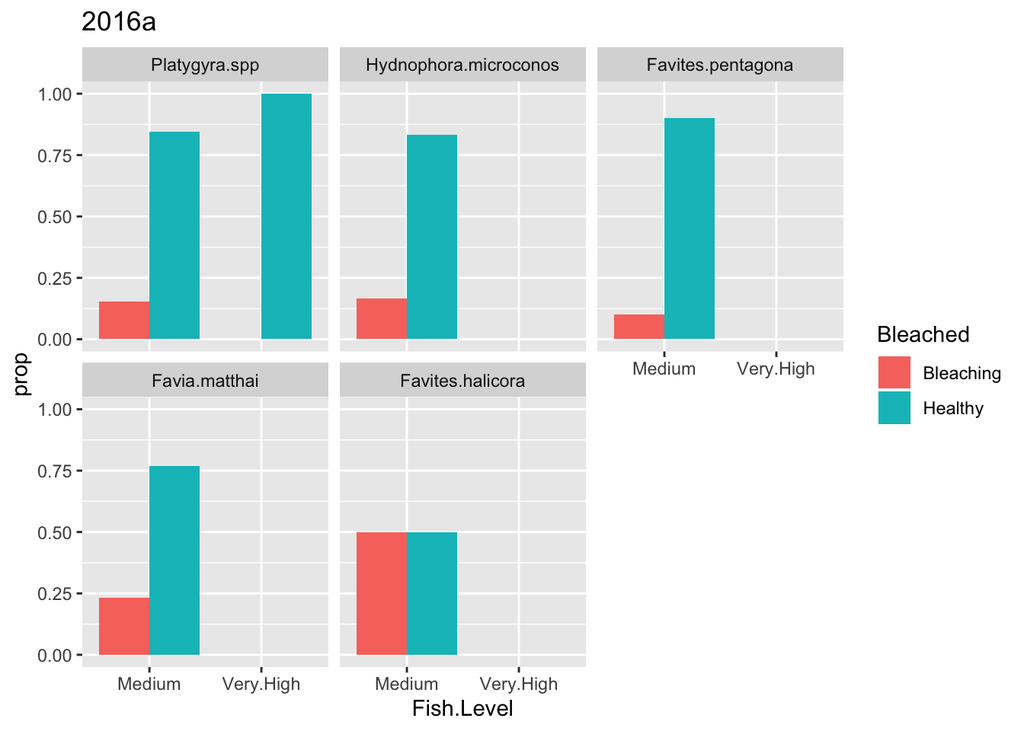

# iv) Compare coral net 2015d to colony specific data (that KT collected) from photos 2015d

**there are no Favid from coral net**

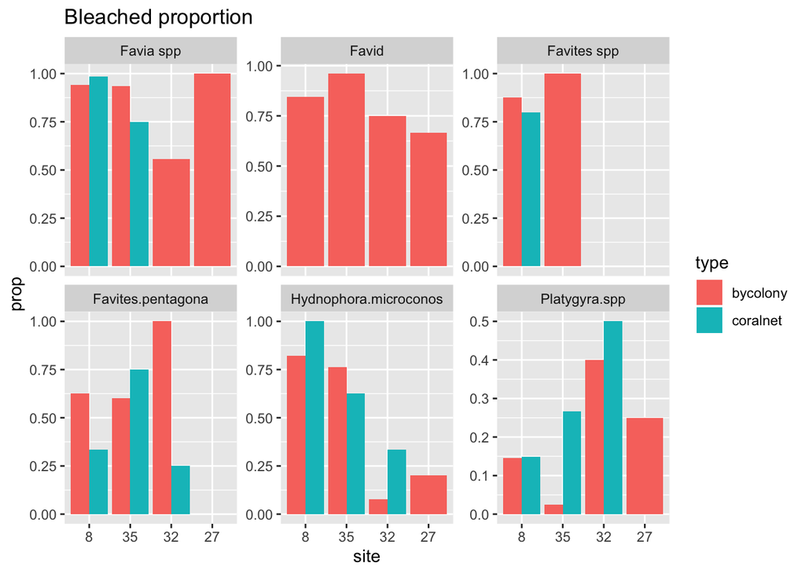

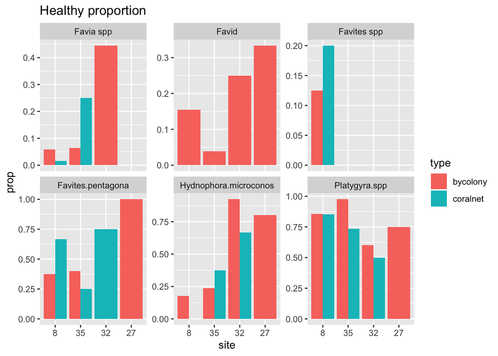